# Matplotlib

## What is matplotlib?

### Matplotlib is a low level graph plotting library in python that serves as a visualization utility.

### Matplotlib was created by John D. Hunter.

## Installation of Matplotlib

### !pip install matplotlib

```python
import matplotlib.pyplot as plt
import pandas as pd
df=pd.read_csv('C:/Users/user/Downloads/kaggle/titanic (1).csv')
df
```

|  | survived | pclass | sex | age | sibsp | parch | fare | embarked | class | who | adult_male | deck | embark_town | alive | alone |
| --- | --- | --- | --- | --- | --- | --- | --- | --- | --- | --- | --- | --- | --- | --- | --- |
| 0 | 0.0 | 3.0 | male | 22.0 | 1 | 0 | 7.2500 | S | Third | man | True | NaN | Southampton | no | False |
| 1 | 1.0 | 1.0 | female | 38.0 | 1 | 0 | 71.2833 | C | First | woman | False | C | Cherbourg | yes | False |
| 2 | 1.0 | 3.0 | female | 26.0 | 0 | 0 | 7.9250 | S | Third | woman | False | NaN | Southampton | yes | True |
| 3 | 1.0 | 1.0 | female | 35.0 | 1 | 0 | 53.1000 | S | First | woman | False | C | Southampton | yes | False |
| 4 | 0.0 | 3.0 | male | 35.0 | 0 | 0 | 8.0500 | S | Third | man | True | NaN | Southampton | no | True |
| ... | ... | ... | ... | ... | ... | ... | ... | ... | ... | ... | ... | ... | ... | ... | ... |
| 886 | 0.0 | 870.0 | male | 27.0 | 0 | 0 | 13.0000 | S | Second | man | True | NaN | Southampton | no | True |
| 887 | 1.0 | 871.0 | female | 19.0 | 0 | 0 | 30.0000 | S | First | woman | False | B | Southampton | yes | True |
| 888 | 0.0 | 872.0 | female | NaN | 1 | 2 | 23.4500 | S | Third | woman | False | NaN | Southampton | no | False |
| 889 | 1.0 | 873.0 | male | 26.0 | 0 | 0 | 30.0000 | C | First | man | True | C | Cherbourg | yes | True |
| 890 | 0.0 | 874.0 | male | 32.0 | 0 | 0 | 7.7500 | Q | Third | man | True | NaN | Queenstown | no | True |

891 rows × 15 columns

## Examples:

### 1.Bar graph

### A bar graph is a visual representation of data using rectangular bars to show the values of different categories. The length or height of each bar corresponds to the data value it represents.

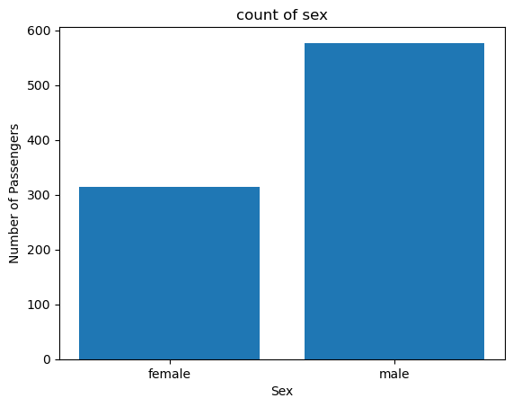

```python
a= df['sex'].value_counts().sort_index()
plt.bar(a.index, a.values)
plt.xlabel('Sex')
plt.ylabel('Number of Passengers')
plt.title('count of sex')
plt.show()
```

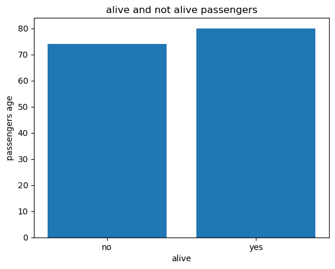

```python
plt.bar(df['alive'],df['age'])
plt.title("alive and not alive passengers")
plt.xlabel("alive")
plt.ylabel("passengers age")
plt.show()
```

### 2.Histogram

### A histogram is a graphical representation that shows the distribution of a numerical dataset using bars. Each bar represents the frequency of data points within a specific range (bin).

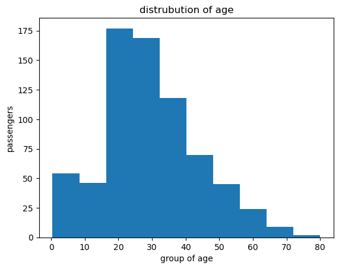

```python
plt.hist(df['age'],bins=10)
plt.title("distrubution of age")
plt.xlabel("group of age")
plt.ylabel("passengers")
plt.show()
```

### 3.line graph

### A line graph is a chart that connects data points with a continuous line to show trends over time or ordered categories. It’s useful for visualizing changes and patterns in data.

```python
a=df['class'].value_counts()
a
```

```
class
Third     491
First     216
Second    184
Name: count, dtype: int64
```

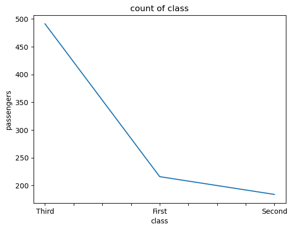

```python
a=df['class'].value_counts()
plt.title("count of class")
plt.xlabel("class")
plt.ylabel("passengers")
a.plot(kind='line')
```

### 4.Scatter plot

### A scatter plot is a graph that displays points to show the relationship between two different variables. Each point represents an observation with values on the x- and y-axes.

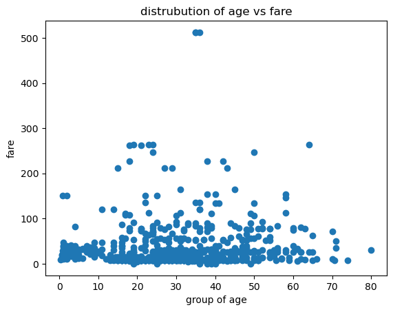

```python
plt.scatter(df['age'],df['fare'])
plt.title("distrubution of age vs fare")
plt.xlabel("group of age")
plt.ylabel("fare")
plt.show()
```

### 5.Piechart

### A pie chart is a circular graph divided into slices to illustrate numerical proportions. Each slice represents a category's contribution to the whole.

[figure not shown]

```python
plt.pie(df['class'].value_counts(),labels=[1,2,3],autopct='%1.2f%%')
plt.show()
```

### 6.Boxplot

### A boxplot is a graphical display that shows the distribution of a dataset through its quartiles. It highlights the median, spread, and potential outliers in the data.

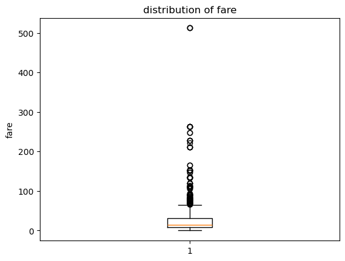

```python
plt.boxplot(df['fare'])
plt.title("distribution of fare")
plt.ylabel("fare")
plt.show()
```

### 7.Subplots

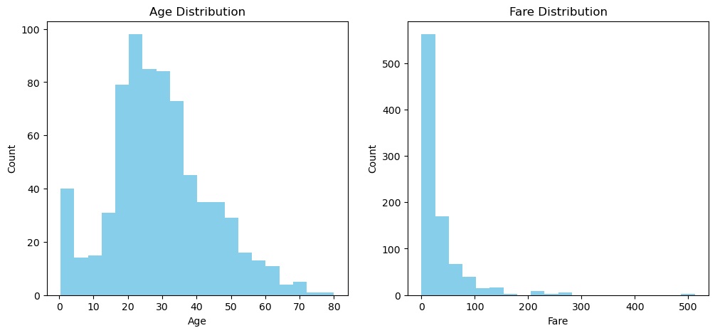

```python
fig, axs = plt.subplots(1, 2, figsize=(12, 5))
axs[0].hist(df['age'].dropna(),bins=20, color='skyblue')
axs[0].set_title('Age Distribution')
axs[0].set_xlabel('Age')
axs[0].set_ylabel('Count')

axs[1].hist(df['fare'].dropna(),bins=20, color='skyblue')
axs[1].set_title('Fare Distribution')
axs[1].set_xlabel('Fare')
axs[1].set_ylabel('Count')
```

```python
df.value_counts()
```

```
survived  pclass  sex     age   sibsp  parch  fare     embarked  class   who    adult_male  deck  embark_town  alive  alone
0.0       1.0     male    54.0  0      0      51.8625  S         First   man    True        E     Southampton  no     True     1
1.0       433.0   male    52.0  0      0      30.5000  S         First   man    True        C     Southampton  yes    True     1
          444.0   male    48.0  0      0      26.5500  S         First   man    True        E     Southampton  yes    True     1
          457.0   female  23.0  0      0      13.7917  C         Second  woman  False       D     Cherbourg    yes    True     1
          468.0   male    25.0  1      0      91.0792  C         First   man    True        B     Cherbourg    yes    False    1
                                                                                                                              ..
          3.0     female  4.0   1      1      16.7000  S         Third   child  False       G     Southampton  yes    False    1
          5.0     male    34.0  0      0      13.0000  S         Second  man    True        D     Southampton  yes    True     1
          7.0     male    28.0  0      0      35.5000  S         First   man    True        A     Southampton  yes    True     1
          36.0    female  49.0  1      0      76.7292  C         First   woman  False       D     Cherbourg    yes    False    1
          873.0   male    26.0  0      0      30.0000  C         First   man    True        C     Cherbourg    yes    True     1
Name: count, Length: 182, dtype: int64
```

### 8.line graph

### A line graph is a chart that displays information as a series of data points connected by straight lines.

### It is commonly used to show trends or changes over time or continuous data.

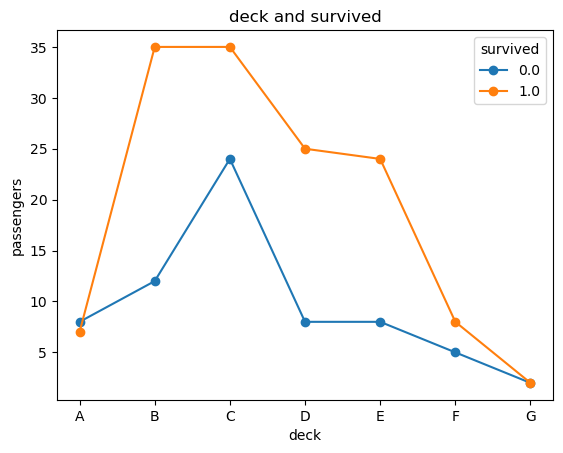

```python
a=df[['deck','survived']].value_counts().unstack()
a.plot(kind='line',marker='o')
plt.title("deck and survived")
plt.xlabel("deck")
plt.ylabel("passengers")
plt.show()
```